# Red Wine Quality Insights by Toni Anev

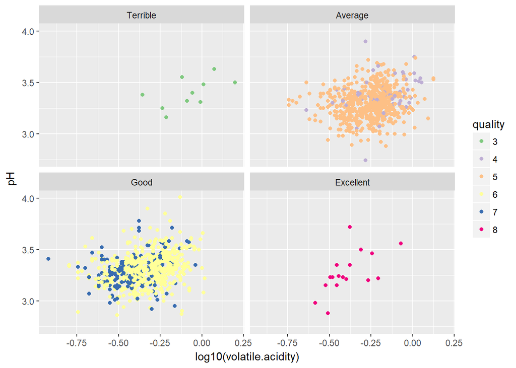

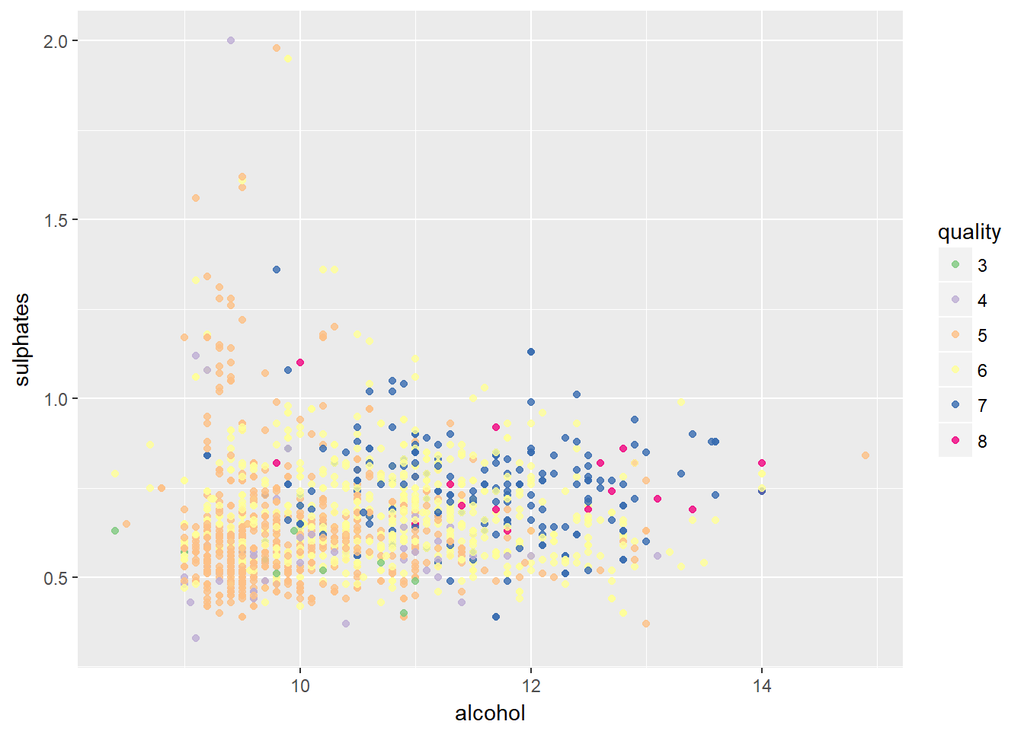

As the two strongest correlates to quality sulphates and alcohol show a fair amount of clustering.

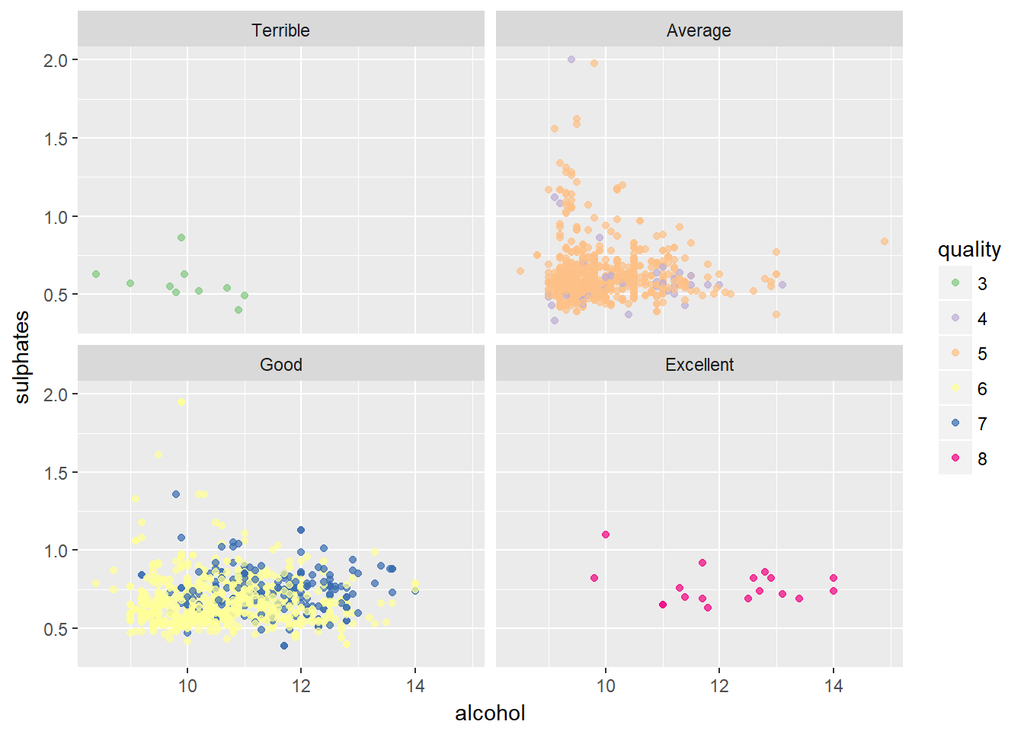

Separating out the clusters by category again shows average and good categories exhibit clustering at the lower end of each axis.

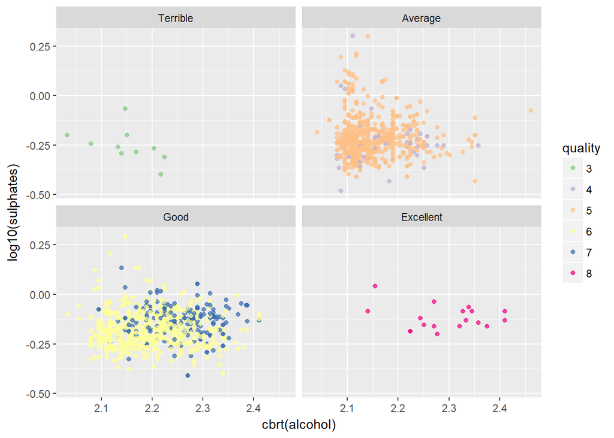

Taking the log of sulphates and cube root of alcohol allows for a better visualization of each point.

```
##
## Call:
## lm(formula = as.numeric(quality) ~ fixed.acidity + density, data = rwq)
##
## Residuals:
##      Min       1Q   Median       3Q      Max
## -2.88657 -0.54850 -0.03066  0.49550  2.55889
##
## Coefficients:
##                 Estimate Std. Error t value Pr(>|t|)
## (Intercept)    200.52094   13.25989   15.12   <2e-16 ***
## fixed.acidity    0.20180    0.01451   13.91   <2e-16 ***
## density       -199.21191   13.38375  -14.88   <2e-16 ***
## ---
## Signif. codes:  0 '***' 0.001 '**' 0.01 '*' 0.05 '.' 0.1 ' ' 1
##
## Residual standard error: 0.7514 on 1596 degrees of freedom
## Multiple R-squared:  0.1354, Adjusted R-squared:  0.1343
## F-statistic:   125 on 2 and 1596 DF,  p-value: < 2.2e-16
```

Looking at the r-squared value for fixed acidity and density as predictors together as predictors of quality however shows a weak ~ 14% correlation.

```
##
## Call:
## lm(formula = as.numeric(quality) ~ alcohol + sulphates + citric.acid +
##     volatile.acidity, data = rwq)
##
## Residuals:
##      Min       1Q   Median       3Q      Max
## -2.71408 -0.38590 -0.06402  0.46657  2.20393
##
## Coefficients:
##                  Estimate Std. Error t value Pr(>|t|)
## (Intercept)       0.64592    0.20106   3.213  0.00134 **
## alcohol           0.30908    0.01581  19.553  < 2e-16 ***
## sulphates         0.69552    0.10311   6.746 2.12e-11 ***
## citric.acid      -0.07913    0.10381  -0.762  0.44605
## volatile.acidity -1.26506    0.11266 -11.229  < 2e-16 ***
## ---
## Signif. codes:  0 '***' 0.001 '**' 0.01 '*' 0.05 '.' 0.1 ' ' 1
##
## Residual standard error: 0.6588 on 1594 degrees of freedom
## Multiple R-squared:  0.3361, Adjusted R-squared:  0.3345
## F-statistic: 201.8 on 4 and 1594 DF,  p-value: < 2.2e-16
```

Looking at the top 4 strongest correlations seem to predict just about ~ 34% of the quality score for the observed wines.

# Multivariate Analysis

### Talk about some of the relationships you observed in this part of the investigation. Were there features that strengthened each other in terms of looking at your feature(s) of interest?

This section I looked at some of the factors affecting quality scores of the sampled wines. Judging from the bivariate analysis I was particularly interested in seeing how the top 4 strongest correlates to quality (Alcohol, Volatile Acidity, Sulphates and Citric Acid) interact to affect the final quality score.

In addition, I looked at some other relationships that stood out to me in the bivariate investigation such as volatile acidity and pH effects on quality,

### Were there any interesting or surprising interactions between features?

One somewhat surprising detail showed that the strong correlation between fixed acidity and density has little impact on the final wine quality score.

# Final Plots and Summary

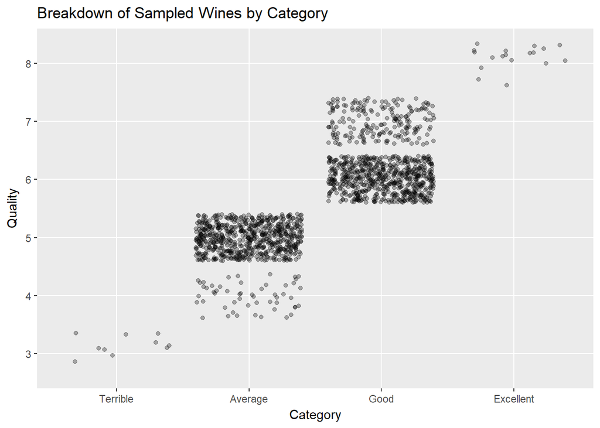

The plot above serves as a good general overview of the observations found in the red wine data set. Naturally most wines are clustered in the 5 - 6 range with some notably excellent and terrible wines.

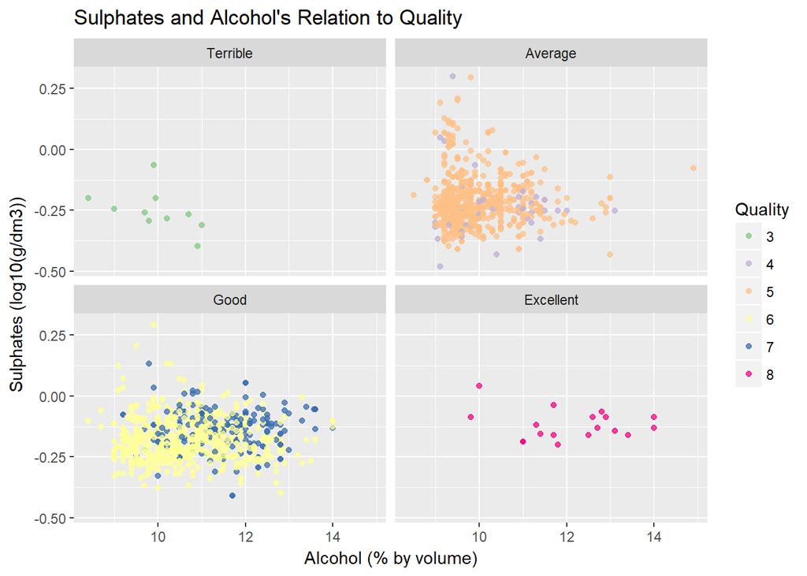

Sulphates and alcohol showed to be the strongest predictors of overall wine quality in my analysis. The plot above shows how different wines are distributed in each category and show an easily accessible overview of how concentration of alcohol and sulphates interrelate to influence overall quality score.

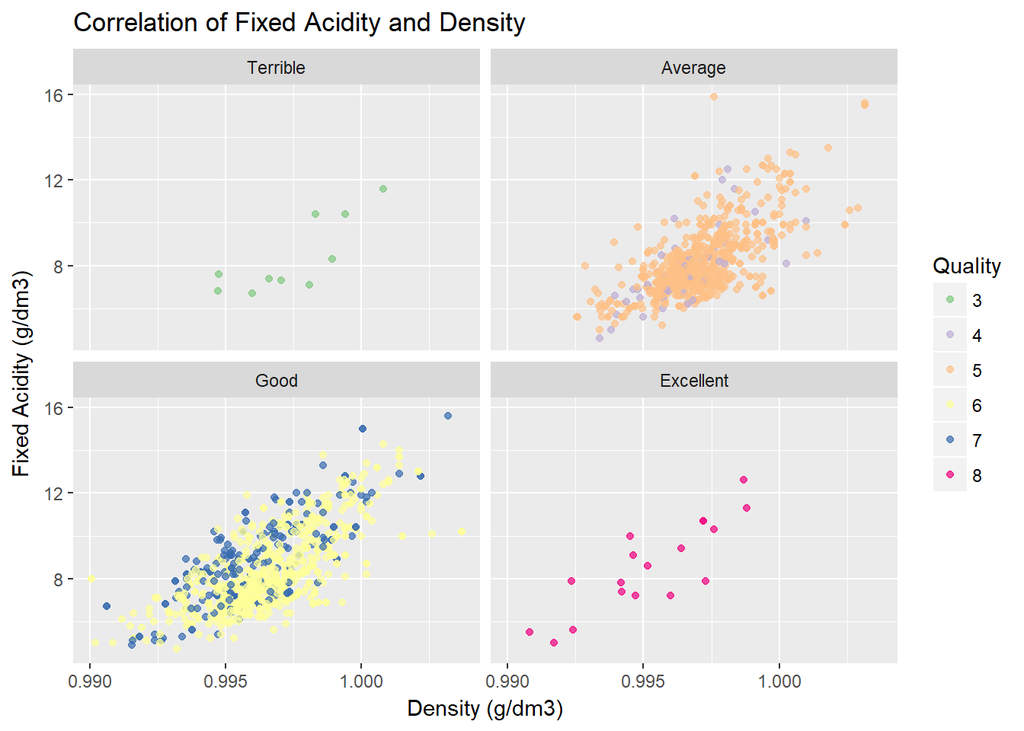

Throughout the investigation I wasn’t able to explain why fixed acidity would be correlated with an increase in density. Doing some additional investigation revealed that the density of tartaric acid (represented as fixed acidity) is 1.79 g/dm3 which is notably higher when compared to water at 1 g/dm3.

# Reflection

Investigating the red wine data set opened my eyes to a lot of factors not only about the composition of red wine but also the process that goes in to making a red wine.

One of the most prominent struggles that I had approaching this analysis was honing in on which variables I wanted to investigate. Luckily, the R corrplot library provided a useful correlation matrix that intuitively visualized different correlations within the dataset.

From there one of the most successful part of my investigation was the ability to quickly prototype and iterate visualizations, especially in the multivariate analysis. I was able to quickly see correlations and manipulate each variables.

One of the more surprising findings was the strong correlation between fixed acidity and density. Although their relationship had a small impact on overall quality it was interesting to find out that tartaric acid was actually the culprit behind the correlation. Although a bit of a dead end it showed me that the analysis and visualizations I was performing were accurate and we showing real correlations.

According to the description attached to the data sample all of the tested wines are of Portuguese origin. It would be interesting to incorporate samples of varying nationalities and run comparisons not only on quality but composition of each wines. Additionally, having a more diverse sample would allow for better predictions and analysis of each wine.

# References

P. Cortez, A. Cerdeira, F. Almeida, T. Matos and J. Reis. Modeling wine preferences by data mining from physicochemical properties. In Decision Support Systems, Elsevier, 47(4):547-553. ISSN: 0167-9236.

http://www.cookbook-r.com/Graphs/Multiple_graphs_on_one_page_(ggplot2)/

https://stackoverflow.com/questions/15633714/adding-a-regression-line-on-a-ggplot

http://sape.inf.usi.ch/quick-reference/ggplot2/geom_jitter

http://ggplot2.tidyverse.org/reference/labs.html

https://cran.r-project.org/web/packages/gridExtra/vignettes/arrangeGrob.html

http://winefolly.com/update/sugar-in-wine-misunderstanding/

https://en.wikipedia.org/wiki/Red_wine

https://cran.r-project.org/web/packages/corrplot/vignettes/corrplot-intro.html

https://en.wikipedia.org/wiki/Citric_acid

https://www.practicalwinery.com/janfeb09/page5.htm

https://rpubs.com/kaz_yos/ggplot2-stat-summary

http://www.sthda.com/english/wiki/ggplot2-point-shapes

http://tutorials.iq.harvard.edu/R/Rgraphics/Rgraphics.html

https://www.everwonderwine.com/blog/2017/1/14/is-there-a-relationship-between-a-wines-alcohol-level-and-its-sweetness

https://www.rstudio.com/wp-content/uploads/2015/03/ggplot2-cheatsheet.pdf

https://stackoverflow.com/questions/46201785/scale-color-brewer-ggplot2-does-not-colour-all-the-lines

http://ggplot.yhathq.com/docs/scale_color_brewer.html

https://stackoverflow.com/questions/9028662/predict-maybe-im-not-understanding-it

https://rtutorialseries.blogspot.ca/2009/12/r-tutorial-series-multiple-linear.html

https://stackoverflow.com/questions/13236158/real-cube-root-of-a-negative-number

https://en.wikipedia.org/wiki/Tartaric_acid